# Lattice Plotting System

Mr. Sachin B.

### 1. Lattice Plotting System

- The lattice plotting system is useful for plotting high dimensional data and for making many plots at once.
- The lattice plotting system is implemented using the following packages.
  1. `lattice`: contains code for producing Trellis graphics, which are independent of the ‘base’ graphics system.
     - includes functions like `xyplot`,`bwplot`,`levelplot`
  2. `grid`: implements a different graphing system independent of the `base` system.
- The `lattice` package builds on top of `grid`. We rarely call functions from the `grid` package directly.
- The lattice system does not have ‘two-phase’ aspect with seperate plotting and annotation like in base plotting.
- All plotting/annotation is done at once with a single function call.

### 2. Lattice Functions

- **xyplot**: this is the main function for creating scatterplots
- **bwplot**: box-and-whiskers plots (“boxplots”)
- **histogram**: histograms
- **stripplot**: like a boxplot but with actual points
- **dotplot**: plot dots on “violin strings”
- **splom**: scatterplot matrix; like pairs in base plotting system
- **levelplot, contourplot**: for plotting “image” data

### 3. Lattice Scatter Plot

#### 3.1. Scatter Plot without condition

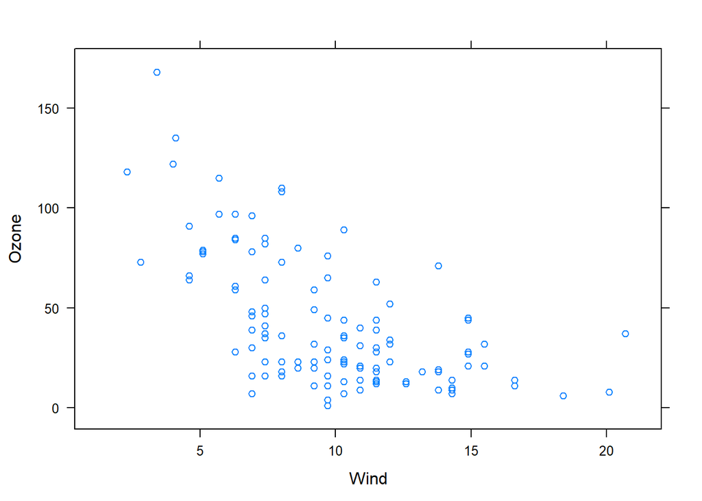

```r
# load lattice package
library(lattice)
library(datasets)

# Simple Scatterplot
xyplot(Ozone~Wind,data=airquality)
```

#### 3.2. Scatter Plot with condition

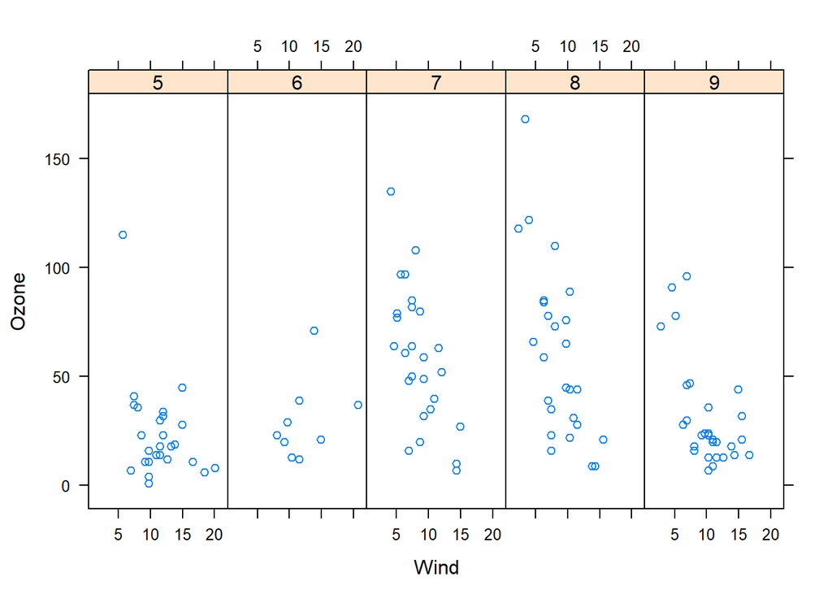

```r
# Convert 'Month' to a factor variable
airquality <- transform(airquality,Month = factor(Month))

# Scatterplot with condition
xyplot(Ozone ~ Wind | Month, data = airquality, layout = c(5,1))
```

### 4. Lattice Behavior

Lattice functions behave differently from base graphics functions in one critical way.

- Base graphics functions plot data directly to the graphics device (screen, PDF file, etc.)
- Lattice graphics functions return an object of class `trellis`
- The `print` methods for lattice functions actually do the work of plotting the data on the graphics device.
- Lattice functions return “plot objects” that can, in principle, be stored (but it’s usually better to just save the code + data).
- On the command line, trellis objects are auto-printed so that it appears the function is plotting the data

Example:

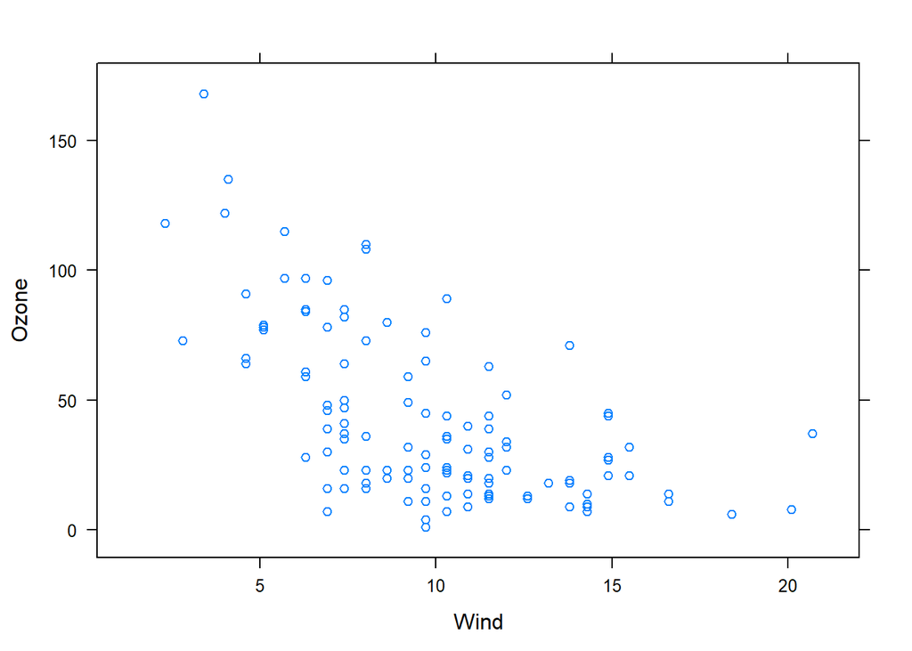

```r
p <- xyplot(Ozone ~ Wind, data = airquality) ## Nothing happens!

print(p) ## Plot appears
```

### 5. Lattice Panel Functions

- Lattice functions have a `panel` function which controls what happens inside each panel of the plot.
- The `lattice` package comes with *default panel functions*, but you can supply your own if you want to customize what happens in each panel
- Panel functions receive the $x/y coordinates$ of the data points in their panel (along with any optional arguments)

#### 5.1 Default Panel Function

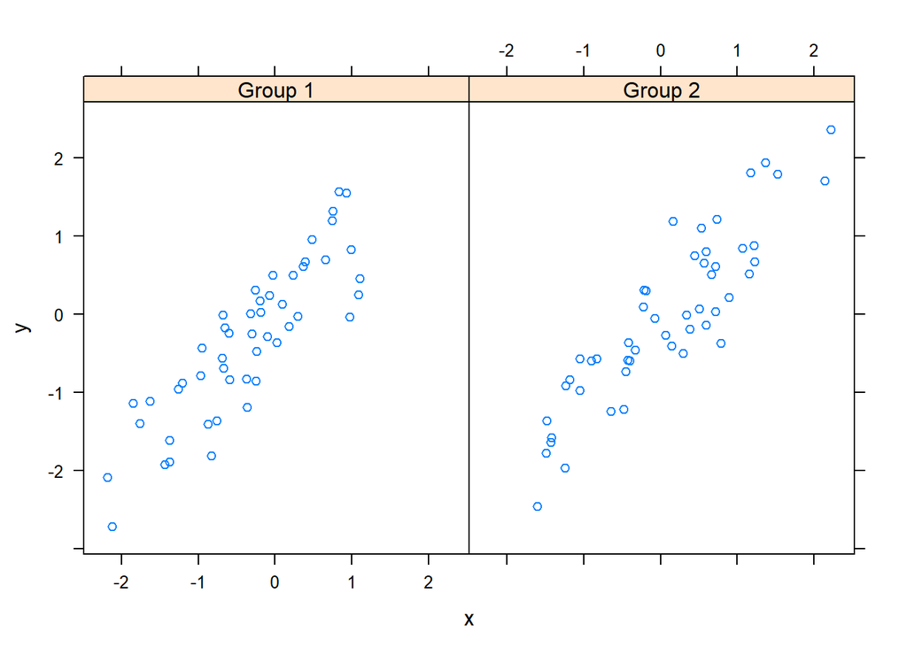

```r
set.seed(10)
x <- rnorm(100)
y <- x + rnorm(100, sd = 0.5)
f <- factor(rep(0:1, each = 50), labels = c("Group 1", "Group 2"))

# Default panel function work for Panel 1 (Group 1) & Panel 2 (Group 2)
xyplot(y ~ x | f, layout = c(2, 1)) ## Plot with 2 panels
```

#### 5.2 Custom Panel Function

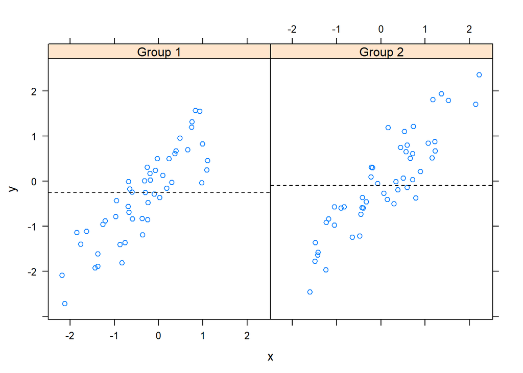

```r
set.seed(10)
x <- rnorm(100)
y <- x + rnorm(100, sd = 0.5)
f <- factor(rep(0:1, each = 50), labels = c("Group 1", "Group 2"))

# Custom panel function work with abline
xyplot(y ~ x | f, panel = function(x, y, ...){
  panel.xyplot(x,y, ...)  ## First call the default panel function for 'xyplot'
  panel.abline(h=median(y), lty = 2)  ## Add a horizontal line at the median
})
```

#### 5.2 Custom panel function: Regression line

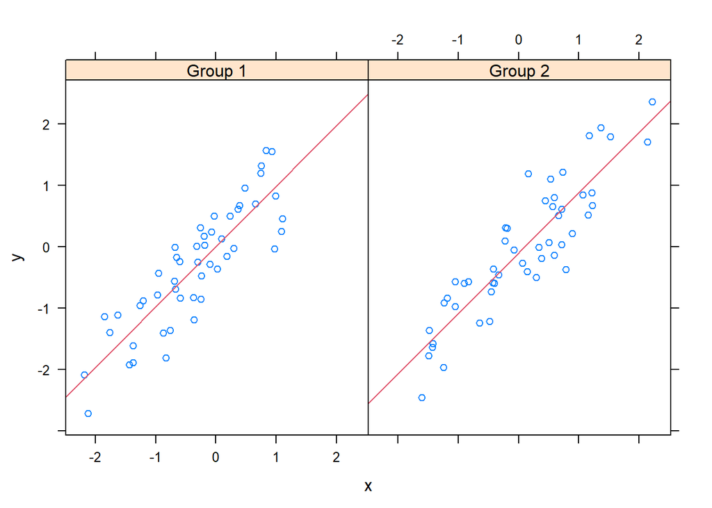

```r
## Custom panel function
xyplot(y ~ x | f, panel = function(x, y, ...) {
 panel.xyplot(x, y, ...) ## First call default panel function
 panel.lmline(x, y, col = 2) ## Overlay a simple linear regression line
})
```